# STAA-566: Data Vis

Assignment 1: ggplot2

Penny Grant

2022-09-18

# Load packages

```r
require(readr)
require(tidyverse)
require(ggthemes)
require(dplyr)
require(lubridate)
require(ggrepel)
require(viridis)
```

# Import Dataset

Citation for Data used:

> North America Land Data Assimilation System (NLDAS) Daily Sunlight (insolation) for years 1979-2011 on CDC WONDER Online Database, released 2013. Accessed at http://wonder.cdc.gov/NASA-INSOLAR.html

*Final column of data frame was edited in the text file as it had an exponent that proved to be problematic*

I used “Import Dataset > From Text (readr)” to import my dataset - removing duplicate columns and formatting the `Month, Year Code` as a date.

```r
regional_sunlight <- read_delim("NLDAS Daily Sunlight By Region.txt",
      delim = "\t",escape_double = FALSE,
      col_types = cols(Notes = col_skip(),
                       `Region Code`= col_skip(), `Month, Year`= col_skip(),
                       `Month, Year Code`=col_date(format = "%Y/%m")),
      trim_ws = TRUE)
```

Make changes to data frame to make it easier to work with, including:

- Remove rows with na values - these are summary rows
- Rename date column
- Recode regions to exclude Census Region #

```r
regional_sunlight <- regional_sunlight %>%
  drop_na() %>%
  rename("YearMo" = "Month, Year Code") %>%
  mutate(Region = recode(Region,"Census Region 1: Northeast" = "Northeast",
                         "Census Region 2: Midwest" = "Midwest",
                         "Census Region 3: South" = "South",
                         "Census Region 4: West" = "West"))
```

Create new data frame filtering out data from 2011 (last year available), to maintain original data frame.

```r
twenty_eleven <- regional_sunlight %>%
  filter(year(YearMo)==2011)
```

# Plot Data

Start with mapping the data, grouping it by Region

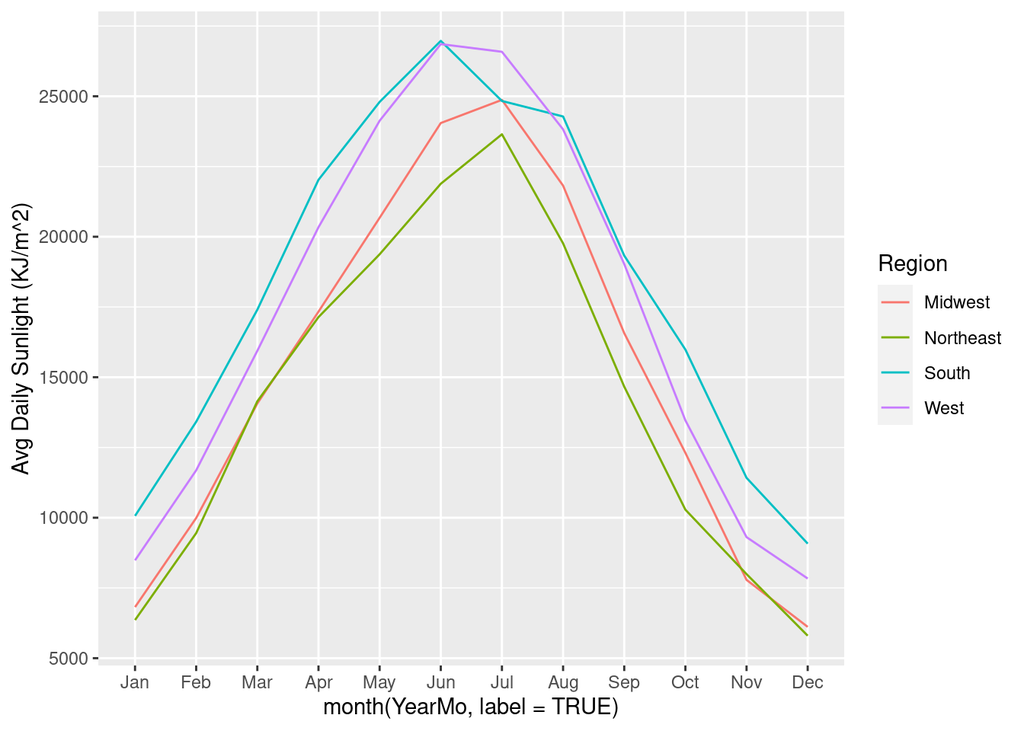

```r
p_sun <- twenty_eleven %>%
  ggplot(mapping = aes(x = month(YearMo,label=TRUE),
                       y = `Avg Daily Sunlight (KJ/m^2)`,
                       group = Region)) +
  geom_line(aes(col = `Region`))

p_sun
```

Adjust the theme

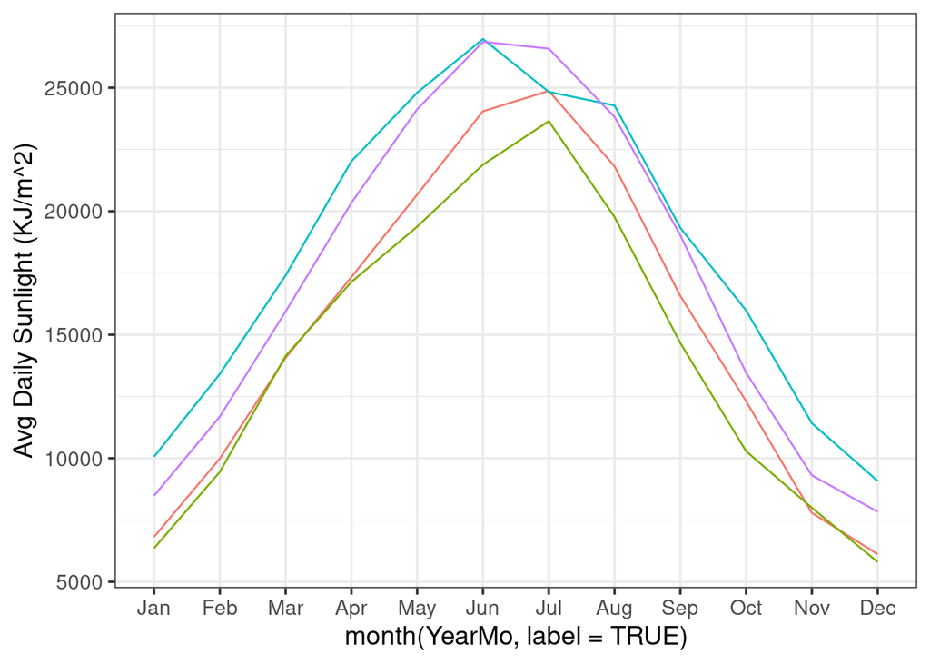

```r
p_sun <- p_sun +
  theme_bw(base_size = 14,base_family = "sans") +
  theme(legend.position = "none")

p_sun
```

Change axes, add descriptive labels & title

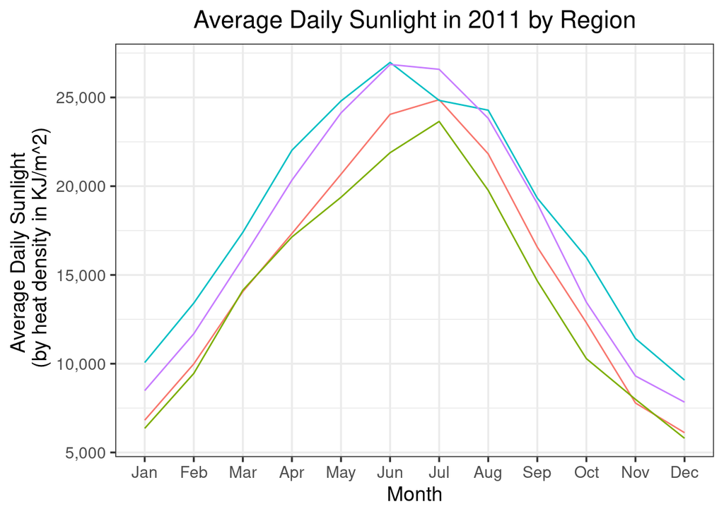

```r
p_sun <- p_sun +
  labs(x="Month",y="Average Daily Sunlight \n (by heat density in KJ/m^2)",
       title = "Average Daily Sunlight in 2011 by Region") +
  scale_y_continuous(labels = scales::label_comma()) +
  theme(plot.title = element_text(hjust = 0.5))

p_sun
```

Set up direct labeling, following the steps shown in class

```r
# find end of lines
line_ends <- ggplot_build(p_sun)$data[[1]] %>%
  group_by(colour) %>%
  filter(x==max(x))

# add region label
line_ends$Region <- regional_sunlight %>% pull(Region) %>%
  unique() %>%
  as.character() %>%
  sort()
```

Finally, add the direct labels to the graph and change the color scale

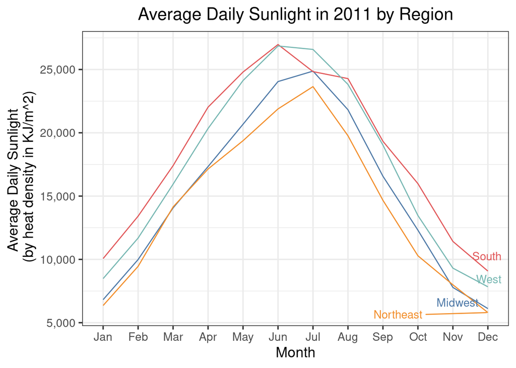

```r
p_sun <- p_sun + ggrepel::geom_label_repel(data = line_ends,
                          aes(x = line_ends$x, y = line_ends$y,
                              label = Region, colour = Region),
                          nudge_x = 1,
                          label.size = NA,
                          fill = alpha(c("white"),0)) +
  scale_color_tableau()

p_sun
```